# **Assignment 10 - Working with genetic data in R**

In this assignment, you will:

- Learn a couple of packages for working with sequence data
- Learn how to import, manipulate, and export genetic data
- Align DNA and build phylogenetic trees

## The CRAN packages we will use include:

- bioseq (gives dedicated DNA, RNA, and AA vector classes … works with tidyverse!)
- ape (Analysis of Phylogenetics and Evolution)
- msa (Multiple Sequence Alignment)
- phangorn (for building and refining phylogenetic trees)

These can all be installed with install.packages()

# Assignment:

**All of this should be done in an Rmd file and knitted to html to turn in**

**1. Go through the brief tutorial below** (this just barely scratches the surface of how to work with DNA sequences in R)

**2. Read in “Homework_1.fasta” and “Homework_2.fasta”**

**3. Combine those files into one**

**4. Build a simple Neighbor-Joining tree of all those sequences**

**5. Build a similar tree out of the reverse-compliments of all those sequences and compare**

### Load our packages

```r
library(bioseq)
library(ape)
library(msa)
library(phangorn)
library(tidyverse)
library(Biostrings)
```

### Read in a fasta file

```r
seqs <- read_fasta("./bacteria_16S.fasta")
seqs[1:3] # take a quick look at them (just the first 3 for now)
```

```
## DNA vector of 3 sequences
## Bacteria;Actinoba...  GAACGCTGGCGGCGTGCTTAACACATGCAAGTCGAACGGAAAGGTCTCTTCGGAGATACT... + 1385 bases
## Bacteria;Proteoba...  GTTTGATCCTGGCTCAGATTGAACGCTGGCGGCAGGCCTAACACATGCAAGTCGAGCGGA... + 1476 bases
## Bacteria;Actinoba...  TAGAGTTTGATCCTGGCTCAGGACGAACGCTGGCGGCGTGCTTAACACATGCAAGTCGAA... + 1422 bases
```

### Handy manipulations

##### Complement

```r
compl <- seq_complement(seqs[1:3])
compl
```

```
## DNA vector of 3 sequences
## Bacteria;Actinoba...  CTTGCGACCGCCGCACGAATTGTGTACGTTCAGCTTGCCTTTCCAGAGAAGCCTCTATGA... + 1385 bases
## Bacteria;Proteoba...  CAAACTAGGACCGAGTCTAACTTGCGACCGCCGTCCGGATTGTGTACGTTCAGCTCGCCT... + 1476 bases
## Bacteria;Actinoba...  ATCTCAAACTAGGACCGAGTCCTGCTTGCGACCGCCGCACGAATTGTGTACGTTCAGCTT... + 1422 bases
```

##### Reverse-Compliment

```r
seq_reverse(compl)
```

```
## DNA vector of 3 sequences
## Bacteria;Actinoba...  ACGACTTCGTCCCAATCGCCGATCCCACCTTCGACAGCTCCCTCCCAAAGGTTAGGCCAC... + 1385 bases
## Bacteria;Proteoba...  GATCCAGCCGCAGGTTCCCCTAGGGCTACCTTGTTACGACTTCACCCCAGTCATGAACCA... + 1476 bases
## Bacteria;Actinoba...  TACGGCTACCTTGTTACGACTTCGTCCCAATCGCCGATCCCACCTTCGACGGCTCCCTCC... + 1422 bases
```

##### Transcribe to RNA

```r
seqs_rna <- seq_transcribe(seqs[1:3])
seqs_rna
```

```
## RNA vector of 3 sequences
## >   GAACGCUGGCGGCGUGCUUAACACAUGCAAGUCGAACGGAAAGGUCUCUUCGGAGAUACU... + 1385 bases
## >   GUUUGAUCCUGGCUCAGAUUGAACGCUGGCGGCAGGCCUAACACAUGCAAGUCGAGCGGA... + 1476 bases
## >   UAGAGUUUGAUCCUGGCUCAGGACGAACGCUGGCGGCGUGCUUAACACAUGCAAGUCGAA... + 1422 bases
```

##### Translate RNA to AA

```r
seq_translate(seqs_rna)
```

```
## AA vector of 3 sequences
## >   ERWRRA*HMQVERKGLFGDTRVANG*VTRG*SALHIGISLGNWV*YRIGPRGACLVVESF... + 421 amino acids
## >   V*SWLRLNAGGRPNTCKSSGNDTNNPSGALMGVERRTGE*CLGNCLDVGDNHWKRWLIPH... + 452 amino acids
## >   *SLILAQDERWRRA*HMQVERKGPSGYSSGERVSNTWVICPALWDKPGKLGLIPNRTTLF... + 434 amino acids
```

### Pattern matching

##### Using ‘regular expressions’

```r
seqs[seq_detect_pattern(seqs,"AAAAA")] # show all seqs that have "AAAAA" anywhere
```

```
## DNA vector of 21 sequences
## Bacteria;Proteoba...  GTTTGATCCTGGCTCAGATTGAACGCTGGCGGCAGGCCTAACACATGCAAGTCGAGCGGA... + 1476 bases
## Bacteria;Proteoba...  ATTGAACGCTGGCGGCATGCCTTACACATGCAAGTCGAACGGTAACGCGGGGCAACCTGG... + 1391 bases
## Bacteria;Actinoba...  GACGAACGCTGGCGGCGTGCTTAACACATGCAAGTCGAGCGGAAAGGCCCTTCGGGGGTA... + 1410 bases
## Bacteria;Proteoba...  ATGGCTCAGAACGAACGCTGGCGGCAGGCCTAACACATGCAAGTCGAGCGAAGCCTTCGG... + 1347 bases
## Bacteria;Actinoba...  TCTGTAAGTAGCAGGAAAGGCCCTTCGGGGTACTCGAGCGGCGAACGGGTGAGTAACACG... + 1343 bases
## Bacteria;Proteoba...  AATGATCATGGCTCAGATTGAACGCTGGCGGCATGCCTAACACATGCAAGTCGAACGGTA... + 1305 bases
## Bacteria;Acidobac...  AGCGAACGCTGGCGGCGTGCTTAACACATGCAAGTCGAACGGGATTTGCGTAGCAATACG... + 1393 bases
## Bacteria;Actinoba...  CAAGTCGAGCGGTAAGGCTCCTTCGGGAGTACACGAGCGGCGAACGGGTGAGTAACACGT... + 1329 bases
## Bacteria;Firmicut...  TGCTTAACACATGCAAGTCGAGCGAGAGAGTCTCTTCGGAGACAATCTAGCGGCGGACGG... + 1387 bases
## Bacteria;Proteoba...  TGCAAGTCGAGCGGAAACGACTTATCTGAACCTTCGGGGAACGTTAAGGGCGTCGAGCGG... + 1340 bases
## Bacteria;Proteoba...  AACGAACGCTGGCGGCAGGCCTAACACATGCAAGTCGAGCGCGCCTTTCGGGGCGAGCGG... + 1324 bases
## Bacteria;Actinoba...  CAAGTCGAGCGGAAAGGCCCTTCGGGGTACTCGAGCGGCGAACGGGTGAGTAACACGTGA... + 1380 bases
## ... with 9 more sequences.
```

```r
seqs[seq_detect_pattern(seqs,"^AAT")] # show all seqs that START WITH "AAT"
```

```
## DNA vector of 3 sequences
## Bacteria;Proteoba...  AATGATCATGGCTCAGATTGAACGCTGGCGGCATGCCTAACACATGCAAGTCGAACGGTA... + 1305 bases
## Bacteria;Actinoba...  AATCAGGACGAACGCTGGCGGCGTGCTTAACACATGCAAGTCGAGCGGTAAGGCCCTTCG... + 1416 bases
## Archaea;Euryarcha...  AATTCGATTTTGATCCTGGCGGAGGCTACCGCTATTGGGTTTCGATTAAGCCATGCAAGT... + 1405 bases
```

##### Using biological sequences instead of just “character strings” is safer

```r
pattern <- dna("ACTWYC") #IUPAC symbols allowed
seq_disambiguate_IUPAC(pattern)
```

```
## [[1]]
## DNA vector of 4 sequences
## >   ACTACC
## >   ACTTCC
## >   ACTATC
## >   ACTTTC
```

```r
seqs[seq_detect_pattern(seqs,pattern)] %>% head(3)
```

```
## DNA vector of 3 sequences
## Bacteria;Proteoba...  GTTTGATCCTGGCTCAGATTGAACGCTGGCGGCAGGCCTAACACATGCAAGTCGAGCGGA... + 1476 bases
## Bacteria;Proteoba...  AAGAGTTTGATCCTGGCTCAGAGCGAACGCTGGCGGCATGCTTAACACATGCAAGTCGCA... + 1326 bases
## Bacteria;Proteoba...  AGGCCTAACACATGCAAGTCGAGCGGTAACACAAGGGAGCTTGCTCCTGAGGTGACGAGC... + 1380 bases
```

### Let’s build a tree!

1. Align DNA sequences
2. Build distance matrix from alignment
3. Calculate tree
4. Plot it

```r
# align the sequences
seqs_set <- DNAStringSet(seqs) # convert for the alignment step
# make names shorter
splits <- names(seqs_set) %>% str_split(";")
splits <- map(splits,`length<-`,7) # back-fill to make sure all elements have length of 7
family <- splits %>% map_chr(5)
genus <- splits %>% map_chr(6)
names(seqs_set) <- paste(family,genus)

# remove seqs that dont have genus assignment
good_taxa <- names(seqs_set) %>% grep(pattern = "NA| $",invert = TRUE)
seqs_set <- seqs_set[good_taxa]

# align using msa package
alignment <- msa(seqs_set,method = "Muscle") # this can take a few minutes
alignment
```

```
## MUSCLE 3.8.31
##
## Call:
##    msa(seqs_set, method = "Muscle")
##
## MsaDNAMultipleAlignment with 48 rows and 1680 columns
##      aln                                                   names
##  [1] ----------------------CCG...TGCGGCTGGA--------------- Natrialbaceae Nat...
##  [2] ---AATTCGATTTTGATCCTGGCGG...TGCGGCTGG---------------- Methanobacteriace...
##  [3] ---------------------GCTC...------------------------- Prevotellaceae Pr...
##  [4] -----TTAGAGTTTGATCCTGGCTC...------------------------- Sphingobacteriace...
##  [5] -----------------CCTGGCTC...------------------------- Puniceicoccaceae ...
##  [6] -------------------------...TG----------------------- Armatimonadaceae ...
##  [7] -------------------------...TGC---------------------- Glycomycetaceae G...
##  [8] -------------------------...------------------------- Nocardioidaceae N...
##  [9] -------------------------...------------------------- Streptomycetaceae...
##  ... ...
## [41] -----TAGAGTTTGATCCATGGCTC...------------------------- Enterobacteriacea...
## [42] -------------------------...------------------------- Enterobacteriacea...
## [43] ----------GTTTGATCCTGGCTC...TGCGGCTGGATC------------- Vibrionaceae Vibrio
## [44] -------------------------...------------------------- Vibrionaceae Vibrio
## [45] -------------------------...------------------------- Acholeplasmatacea...
## [46] -------------------------...------------------------- Clostridiaceae_1 ...
## [47] -----TTGAGTTTTTGATCTGGCTC...------------------------- Bacillaceae_1 Bac...
## [48] ----------------------CTC...------------------------- Bacillaceae_1 Bac...
##  Con -------------------------...------------------------- Consensus
```

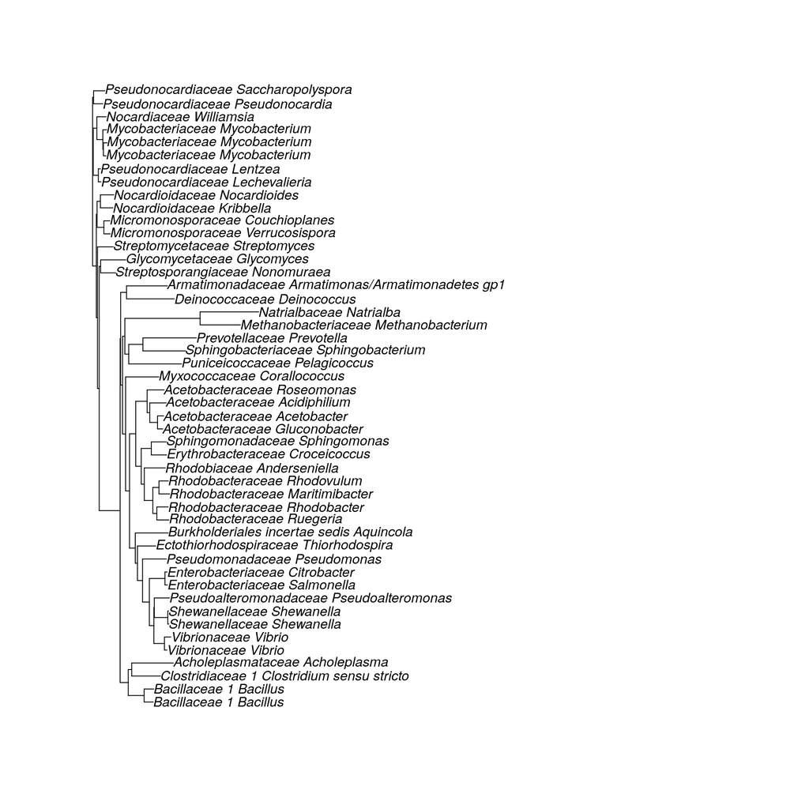

```r
dist <- dist.dna(as.DNAbin(alignment)) # make a simple distance matrix based on DNA position differences (has to be in DNAbin format)
NJ <- bionj(dist) # calculate simple neighbor-joining tree
plot(NJ)
```

### Turn in:

**1. Upload your rmd and html to your GitHub repository under “Assignment_10” directory**

**2. On Canvas, upload a png image file showing your second tree plot so I know your GitHub repo is ready for grading**

# Bonus stuff:

##### Condense tree tips based on phylogeny (group species together into single tips)

```r
seqs_chr <- seqs_set %>% as.character()
seq_df <- data.frame(sequence=dna(seqs_chr),label=names(seqs_chr))
seq_glom <- seq_df %>% group_by(label) %>%
  summarize(taxa_group = paste(label, collapse = "/"),
            consensus_seq = seq_consensus(dna(sequence)))
```

##### rebuild tree with condensed taxa

```r
names(seq_glom$consensus_seq) <- seq_glom$taxa_group
alignment2 <- seq_glom$consensus_seq %>%
  DNAStringSet(use.names = TRUE) %>%
  msa(method="Muscle")
```

```r
pd <- as.phyDat(alignment2) # convert alignment to phyDat (noticing a pattern of how each package has its own formats?)
dm  <- dist.ml(pd) # maximum likelihood distance matrix
treeUPGMA  <- upgma(dm) # build UPGMA tree
treeNJ  <- NJ(dm) # build alternative Neighbor-Joining tree like before
```

Quick look at those trees

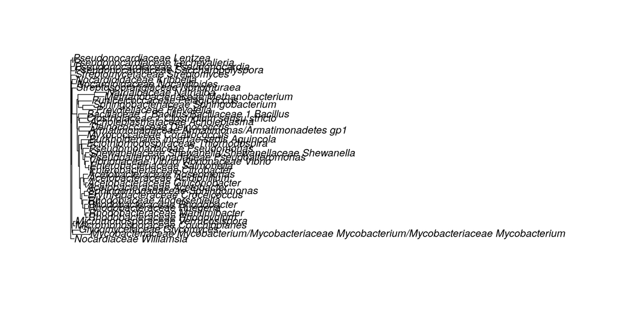

```r
plot(treeNJ)
```

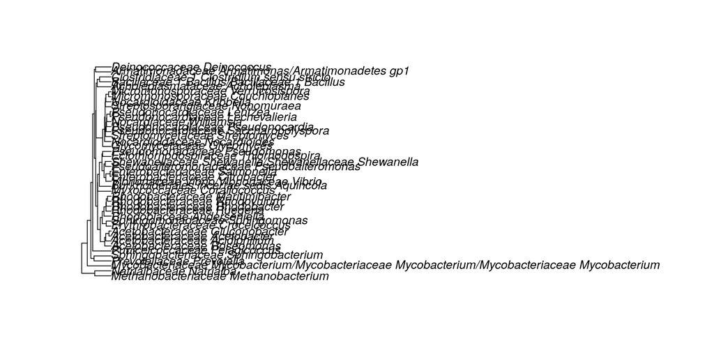

```r
plot(treeUPGMA)
```

**Find alternate tree with lower parsimony by randomly rearranging tips**

```r
treePars  <- optim.parsimony(treeUPGMA, pd)
```

```
## Final p-score 5947 after  16 nni operations
```

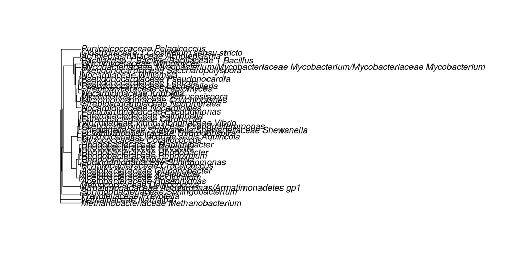

```r
plot(treePars)
```

**Using Maximum Likelihood**

```r
fit = pml(treeNJ, data=pd)
fitJC  <- optim.pml(fit, TRUE) # Optimize fit to Jukes-Cantor substitution model
```

```
## optimize edge weights:  -30028.09 --> -29631.89
## optimize edge weights:  -29631.89 --> -29631.89
## optimize topology:  -29631.89 --> -29558.18
## optimize topology:  -29558.18 --> -29541.65
## optimize topology:  -29541.65 --> -29541.65
## 8
## optimize edge weights:  -29541.65 --> -29541.65
## optimize topology:  -29541.65 --> -29541.65
## 0
## optimize edge weights:  -29541.65 --> -29541.65
```

**Bootstrap analysis**

```r
bs = bootstrap.pml(fitJC, bs=100, optNni=TRUE, control = pml.control(trace = 0)) # this takes a bit of time
```

[output not shown]

[output cut: 45 more lines]

[output not shown]

```r
# It's rebuilding the tree 100 times and seeing how many times each node is returned in those stochastic simulations
```

**Bootstrap values show what percentage of times that node was resolved… i.e., how confident are we in that relationship**

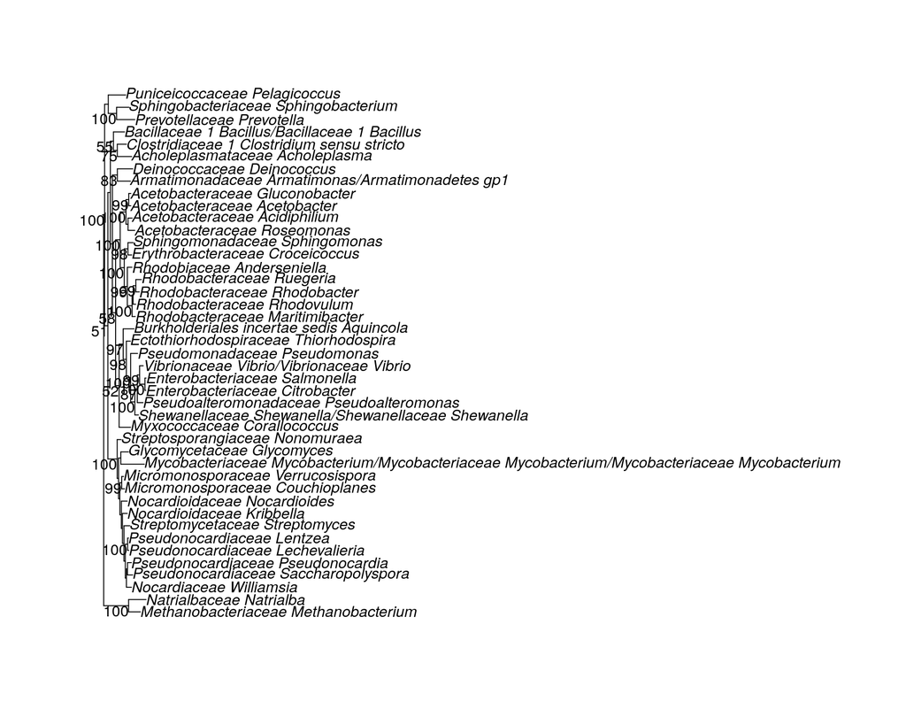

```r
plotBS(midpoint(fitJC$tree), bs, p = 50, type="p")
```

##### Other ‘ape’ functions:

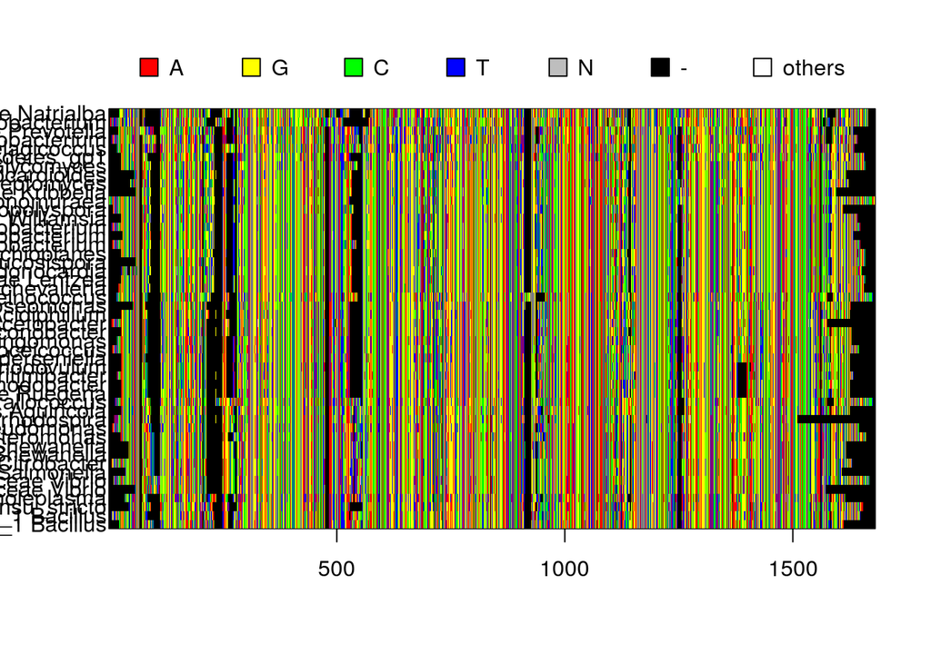

```r
# Image of alignment profile
ape::image.DNAbin(as.DNAbin(alignment))
```

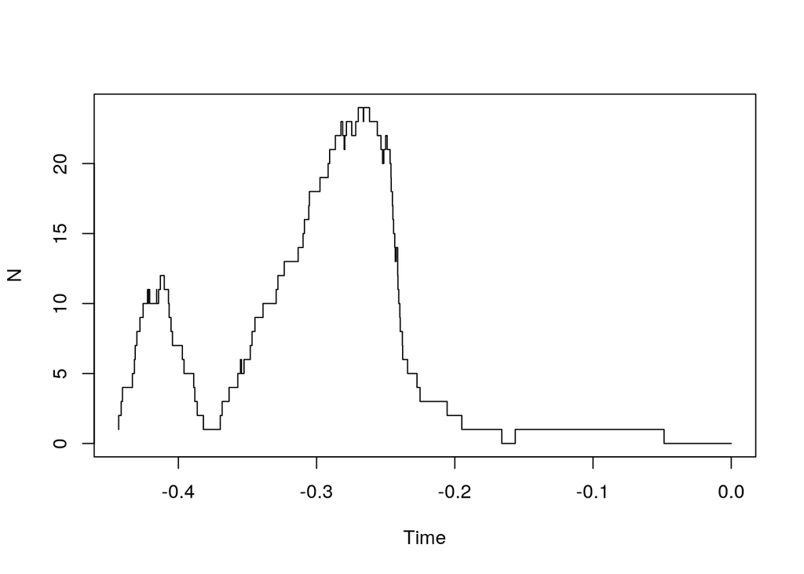

```r
# Number of new lineages over evolutionary time
ape::ltt.plot(NJ)
```

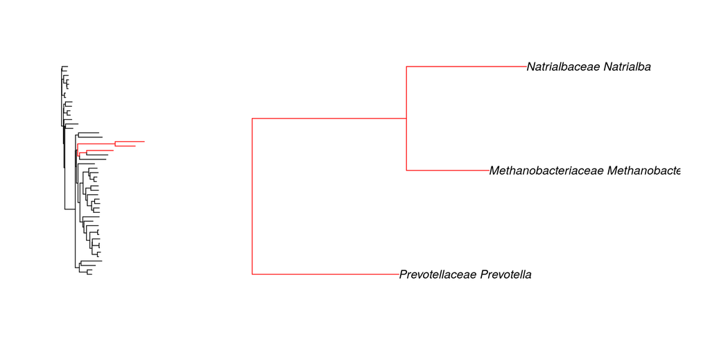

```r
# zoom in on section of tree by passing it the tips of interest
ape::zoom(NJ, c(1:3))
```